# GEOG-5680 Project 2

Owen Harlacker

June 21, 2023

```r
library(dplyr, quietly = TRUE)
```

```r
library(ggplot2, quietly=TRUE)
library(data.table, quietly=TRUE)
library(knitr)
library(kableExtra)
library(GGally)
```

## Part 1: Exploring the data

**Import the file and run some basic info functions**

```r
forbes <- fread('./Forbes2000.csv')
forbes$antirank <- (nrow(forbes)-forbes$rank)
```

**A few graphs**

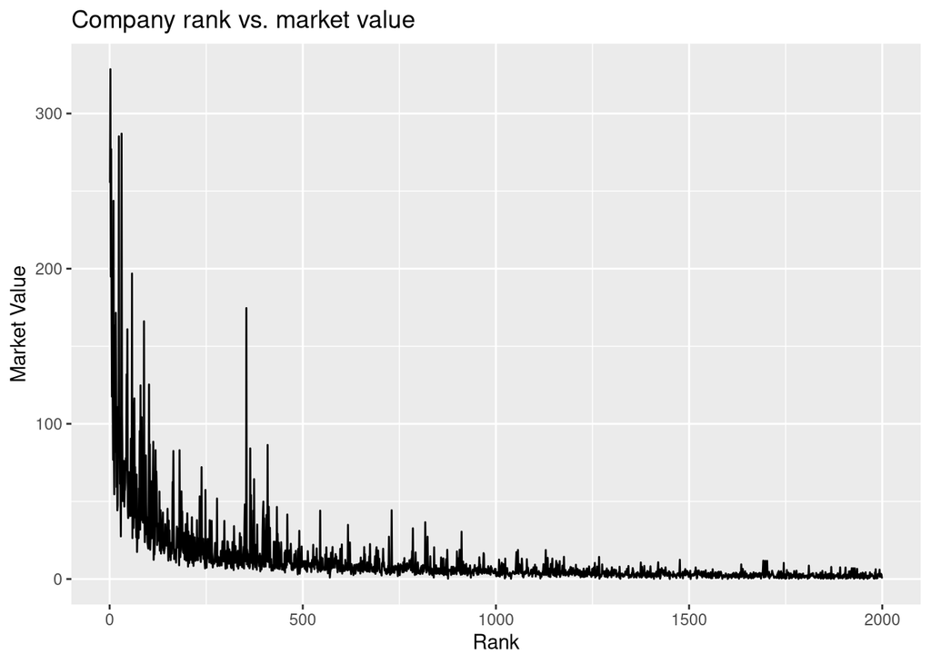

```r
ggplot(forbes, aes(x=rank, y=marketvalue)) + geom_line()+labs(x='Rank', y='Market Value', title = 'Company rank vs. market value')
```

Company types

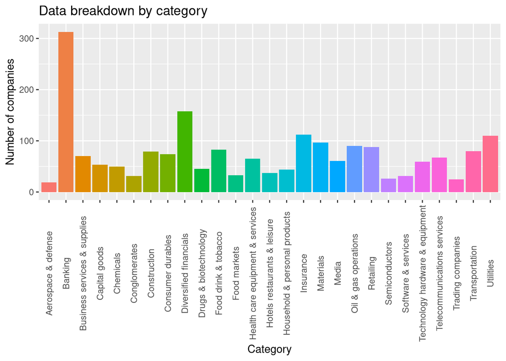

```r
 ggplot(forbes, aes(x=category, fill = category))+ geom_bar()+theme(axis.text.x = element_text(angle = 90, vjust = 0.5))+theme(legend.position="none")+labs(x='Category', y='Number of companies', title = 'Data breakdown by category')
```

Top performer for each country

```r
maxCountry <- forbes[forbes[,.I[profits == max(profits, na.rm = TRUE)], by=country]$V1]
maxCountry <- maxCountry[!is.na(name)]

maxCountry %>% kable %>% kable_styling("striped", full_width = F) %>% scroll_box( height = "400px")
```

| V1 | rank | name | country | category | sales | profits | assets | marketvalue | antirank |
| --- | --- | --- | --- | --- | --- | --- | --- | --- | --- |
| 4 | 4 | ExxonMobil | United States | Oil & gas operations | 222.88 | 20.96 | 166.99 | 277.02 | 1996 |
| 5 | 5 | BP | United Kingdom | Oil & gas operations | 232.57 | 10.27 | 177.57 | 173.54 | 1995 |
| 8 | 8 | Toyota Motor | Japan | Consumer durables | 135.82 | 7.99 | 171.71 | 115.40 | 1992 |
| 32 | 32 | Nestlé | Switzerland | Food drink & tobacco | 64.56 | 5.48 | 62.15 | 106.55 | 1968 |
| 12 | 12 | ING Group | Netherlands | Diversified financials | 94.72 | 4.73 | 752.49 | 54.59 | 1988 |
| 13 | 13 | Royal Dutch/Shell Group | Netherlands/ United Kingdom | Oil & gas operations | 133.50 | 8.40 | 100.72 | 163.45 | 1987 |
| 17 | 17 | Total | France | Oil & gas operations | 131.64 | 8.84 | 87.84 | 116.64 | 1983 |
| 21 | 21 | DaimlerChrysler | Germany | Consumer durables | 157.13 | 5.12 | 195.58 | 47.43 | 1979 |
| 37 | 37 | ENI | Italy | Oil & gas operations | 53.29 | 4.82 | 67.91 | 76.13 | 1963 |
| 39 | 39 | Banco Santander Central | Spain | Banking | 28.70 | 3.28 | 442.24 | 56.78 | 1961 |
| 45 | 45 | Samsung Electronics | South Korea | Semiconductors | 50.22 | 5.95 | 54.58 | 72.72 | 1955 |
| 55 | 55 | PetroChina | China | Oil & gas operations | 29.53 | 5.67 | 58.36 | 90.49 | 1945 |
| 194 | 194 | ACE | Bermuda | Insurance | 10.67 | 1.39 | 49.52 | 12.60 | 1806 |
| 79 | 79 | Royal Bank of Canada | Canada | Banking | 18.82 | 2.28 | 305.01 | 31.82 | 1921 |
| 83 | 83 | Nokia | Finland | Technology hardware & equipment | 37.05 | 4.52 | 29.15 | 104.30 | 1917 |
| 86 | 86 | Natl Australia Bank | Australia | Banking | 15.34 | 2.69 | 269.94 | 36.51 | 1914 |
| 87 | 87 | Gazprom | Russia | Oil & gas operations | 19.21 | 3.81 | 77.15 | 36.28 | 1913 |
| 99 | 99 | Dexia | Belgium | Banking | 19.62 | 1.36 | 368.37 | 21.64 | 1901 |
| 112 | 112 | China Mobile (HK) Hong | Kong/China | Telecommunications services | 15.53 | 3.96 | 34.36 | 67.08 | 1888 |
| 117 | 117 | Statoil Group | Norway | Oil & gas operations | 35.02 | 2.36 | 29.01 | 23.55 | 1883 |
| 122 | 122 | BHP Billiton | Australia/ United Kingdom | Materials | 17.86 | 2.13 | 28.43 | 57.43 | 1878 |
| 127 | 127 | Petrobras-Petrsleo Brasil | Brazil | Oil & gas operations | 22.61 | 2.29 | 27.06 | 35.52 | 1873 |
| 133 | 133 | Den Danske Bank | Denmark | Banking | 12.64 | 1.57 | 308.62 | 16.39 | 1867 |
| 136 | 136 | Nordea | Sweden | Banking | 13.42 | 0.93 | 262.20 | 20.14 | 1864 |
| 144 | 144 | Hutchison Whampoa | Hong Kong/China | Conglomerates | 9.65 | 1.83 | 63.53 | 35.38 | 1856 |
| 188 | 188 | Rio Tinto | United Kingdom/ Australia | Materials | 10.01 | 1.64 | 24.08 | 43.52 | 1812 |
| 221 | 221 | Allied Irish Banks | Ireland | Banking | 6.80 | 1.10 | 89.95 | 15.04 | 1779 |
| 273 | 273 | Oil & Natural Gas | India | Oil & gas operations | 7.01 | 2.20 | 15.75 | 23.26 | 1727 |
| 259 | 259 | Carnival Corp | Panama/ United Kingdom | Hotels restaurants & leisure | 5.93 | 1.18 | 23.40 | 37.96 | 1741 |
| 360 | 360 | Chunghwa Telecom | Taiwan | Telecommunications services | 5.08 | 1.25 | 13.44 | 15.89 | 1640 |
| 318 | 318 | Singapore Telecom | Singapore | Telecommunications services | 5.82 | 0.79 | 18.55 | 23.85 | 1682 |
| 1051 | 1051 | Remgro | South Africa | Conglomerates | 1.11 | 1.11 | 3.89 | 5.62 | 949 |
| 720 | 720 | OMV Group | Austria | Oil & gas operations | 7.44 | 0.33 | 6.30 | 4.45 | 1280 |
| 375 | 375 | Cemex | Mexico | Construction | 7.19 | 0.63 | 15.88 | 9.93 | 1625 |
| 442 | 442 | Portugal Telecom | Portugal | Telecommunications services | 5.87 | 0.41 | 12.64 | 14.25 | 1558 |
| 461 | 461 | PTT Public Company | Thailand | Oil & gas operations | 9.27 | 0.57 | 6.83 | 12.37 | 1539 |
| 515 | 515 | Malayan Banking | Malaysia | Banking | 2.51 | 0.53 | 42.08 | 9.76 | 1485 |
| 746 | 746 | Yapi ve Kredi | Turkey | Banking | 4.48 | 0.90 | 19.83 | 1.86 | 1254 |
| 658 | 658 | Public Power | Greece | Utilities | 3.59 | 0.50 | 10.87 | 6.49 | 1342 |
| 1377 | 1377 | Espirito Santo Finl | Luxembourg | Banking | 2.60 | -0.05 | 47.89 | 0.94 | 623 |
| 668 | 668 | Seagate Technology Cayman | Islands | Technology hardware & equipment | 6.67 | 0.74 | 4.04 | 7.90 | 1332 |
| 675 | 675 | Royal Caribbean | Liberia | Hotels restaurants & leisure | 3.78 | 0.28 | 11.32 | 8.09 | 1325 |
| 791 | 791 | Telekom Indonesia | Indonesia | Telecommunications services | 2.40 | 0.93 | 4.74 | 9.18 | 1209 |
| 792 | 792 | Teva Pharmaceutical Inds | Israel | Drugs & biotechnology | 2.52 | 0.41 | 4.63 | 17.17 | 1208 |
| 840 | 840 | Reed Elsevier | United Kingdom/ Netherlands | Media | 7.54 | 0.14 | 2.51 | 20.46 | 1160 |
| 896 | 896 | Telecom of New Zealand | New Zealand | Telecommunications services | 2.64 | 0.42 | 4.55 | 7.48 | 1104 |
| 1864 | 1864 | Metro Cash and Carry South | Africa | Food markets | 7.10 | 0.06 | 1.27 | 0.66 | 136 |
| 951 | 951 | Antarchile | Chile | Diversified financials | 3.39 | 0.24 | 6.45 | 4.34 | 1049 |
| 962 | 962 | Arab Bank | Jordan | Banking | 1.33 | 0.23 | 22.78 | 4.19 | 1038 |
| 1002 | 1002 | MOL | Hungary | Oil & gas operations | 5.16 | 0.29 | 4.20 | 3.15 | 998 |
| 998 | 998 | S-Oil South | Korea | Oil & gas operations | 6.26 | 0.16 | 4.25 | 4.39 | 1002 |
| 1073 | 1073 | PKN Orlen | Poland | Oil & gas operations | 4.41 | 0.28 | 3.99 | 3.08 | 927 |
| 1740 | 1740 | Fresh Del Monte | Cayman Islands | Food drink & tobacco | 2.40 | 0.24 | 1.45 | 1.44 | 260 |
| 1125 | 1125 | Cez | Czech Republic | Utilities | 1.85 | 0.28 | 7.69 | 3.95 | 875 |
| 1410 | 1410 | Pakistan Telecom | Pakistan | Telecommunications services | 1.23 | 0.41 | 2.35 | 3.50 | 590 |
| 1489 | 1489 | Investec | United Kingdom/ South Africa | Diversified financials | 2.06 | -0.10 | 23.46 | 2.51 | 511 |
| 1497 | 1497 | Eurotunnel | France/ United Kingdom | Transportation | 1.01 | -2.83 | 14.88 | 3.29 | 503 |
| 1674 | 1674 | San Miguel | Philippines | Food drink & tobacco | 2.55 | 0.12 | 3.31 | 3.05 | 326 |
| 1754 | 1754 | Teekay Shipping | Bahamas | Transportation | 1.35 | 0.20 | 3.62 | 2.55 | 246 |
| 1861 | 1861 | Mercantil Servicios Fin | Venezuela | Diversified financials | 0.98 | 0.12 | 6.69 | 0.47 | 139 |
| 1944 | 1944 | Buenaventura | Peru | Materials | 0.17 | 0.11 | 0.62 | 3.68 | 56 |

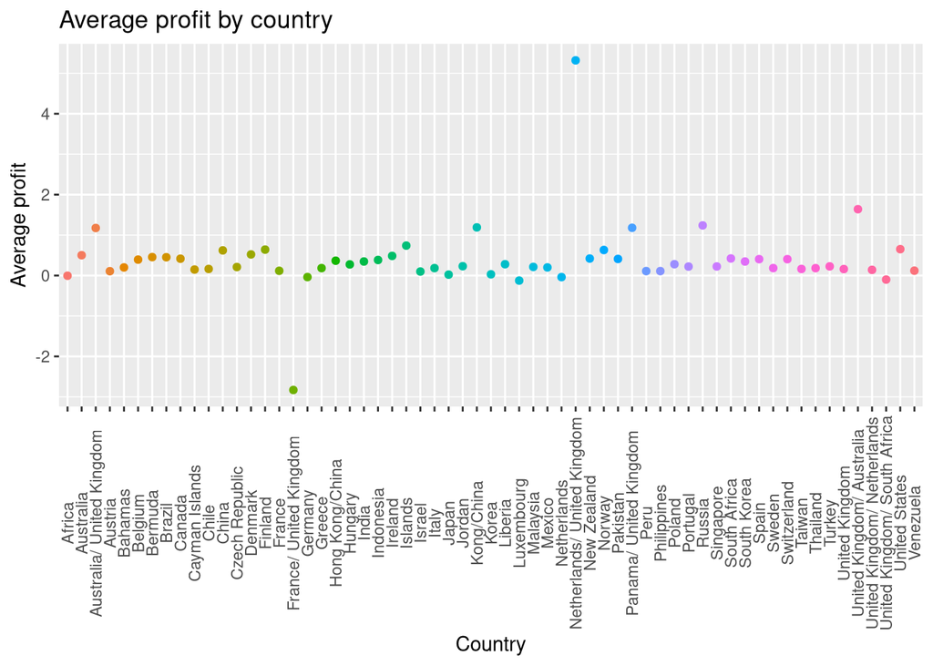

```r
# Average profit per country
forbes %>% group_by(country) %>% summarise(meanProfit = mean(profits, na.rm = TRUE))%>% ggplot( aes(x=country,y=meanProfit, color = country))+geom_point()+theme(axis.text.x = element_text(angle = 90, vjust = 0.5), legend.position = 'none')+labs(x='Country', y='Average profit', title = 'Average profit by country')
```

## Part 2: USA vs. Japan

### US Companies

```r
usComp <- forbes[country== 'United States']
nrow(usComp)
```

```
## [1] 751
```

```r
usComp %>% kable %>% kable_styling("striped", full_width = F) %>% scroll_box(height = "350px")
```

| V1 | rank | name | country | category | sales | profits | assets | marketvalue | antirank |
| --- | --- | --- | --- | --- | --- | --- | --- | --- | --- |
| 1 | 1 | Citigroup | United States | Banking | 94.71 | 17.85 | 1264.03 | 255.30 | 1999 |
| 2 | 2 | General Electric | United States | Conglomerates | 134.19 | 15.59 | 626.93 | 328.54 | 1998 |
| 3 | 3 | American Intl Group | United States | Insurance | 76.66 | 6.46 | 647.66 | 194.87 | 1997 |
| 4 | 4 | ExxonMobil | United States | Oil & gas operations | 222.88 | 20.96 | 166.99 | 277.02 | 1996 |
| 6 | 6 | Bank of America | United States | Banking | 49.01 | 10.81 | 736.45 | 117.55 | 1994 |
| 9 | 9 | Fannie Mae | United States | Diversified financials | 53.13 | 6.48 | 1019.17 | 76.84 | 1991 |
| 10 | 10 | Wal-Mart Stores | United States | Retailing | 256.33 | 9.05 | 104.91 | 243.74 | 1990 |
| 14 | 14 | Berkshire Hathaway | United States | Insurance | 56.22 | 6.95 | 172.24 | 141.14 | 1986 |
| 15 | 15 | JP Morgan Chase | United States | Banking | 44.39 | 4.47 | 792.70 | 81.94 | 1985 |
| 16 | 16 | IBM | United States | Technology hardware & equipment | 89.13 | 7.58 | 104.46 | 171.54 | 1984 |
| 20 | 20 | Freddie Mac | United States | Diversified financials | 46.26 | 10.09 | 752.25 | 44.25 | 1980 |
| 22 | 22 | Altria Group | United States | Food drink & tobacco | 60.70 | 9.20 | 96.18 | 111.02 | 1978 |
| 23 | 23 | ChevronTexaco | United States | Oil & gas operations | 112.94 | 7.43 | 82.36 | 92.49 | 1977 |
| 24 | 24 | Pfizer | United States | Drugs & biotechnology | 40.36 | 6.20 | 120.06 | 285.27 | 1976 |
| 25 | 25 | Wells Fargo | United States | Banking | 31.80 | 6.20 | 387.80 | 97.53 | 1975 |
| 26 | 26 | Verizon Commun | United States | Telecommunications services | 67.75 | 2.57 | 165.97 | 103.97 | 1974 |
| 28 | 28 | Morgan Stanley | United States | Diversified financials | 33.00 | 3.64 | 580.63 | 64.81 | 1972 |
| 29 | 29 | General Motors | United States | Consumer durables | 185.52 | 3.82 | 450.00 | 27.47 | 1971 |
| 31 | 31 | Microsoft | United States | Software & services | 34.27 | 8.88 | 85.94 | 287.02 | 1969 |
| 33 | 33 | SBC Communications | United States | Telecommunications services | 39.16 | 5.97 | 100.17 | 82.93 | 1967 |
| 38 | 38 | ConocoPhillips | United States | Oil & gas operations | 90.49 | 4.83 | 81.95 | 46.72 | 1962 |
| 40 | 40 | Merrill Lynch | United States | Diversified financials | 26.64 | 3.47 | 485.77 | 57.52 | 1960 |
| 41 | 41 | Wachovia | United States | Banking | 24.47 | 4.25 | 400.87 | 62.35 | 1959 |
| 42 | 42 | Time Warner | United States | Media | 38.08 | 2.65 | 121.78 | 77.95 | 1958 |
| 43 | 43 | Hewlett-Packard | United States | Technology hardware & equipment | 73.06 | 2.54 | 74.71 | 70.20 | 1957 |
| 44 | 44 | Procter & Gamble | United States | Household & personal products | 46.99 | 5.81 | 53.86 | 131.89 | 1956 |
| 46 | 46 | Johnson & Johnson | United States | Drugs & biotechnology | 40.01 | 6.74 | 46.66 | 160.96 | 1954 |
| 50 | 50 | American Express | United States | Diversified financials | 24.17 | 3.00 | 175.00 | 68.89 | 1950 |
| 52 | 52 | Bank One | United States | Banking | 21.04 | 3.40 | 290.01 | 58.38 | 1948 |
| 56 | 56 | Goldman Sachs Group | United States | Diversified financials | 22.84 | 2.54 | 394.14 | 50.12 | 1944 |

[output cut: 721 more lines]

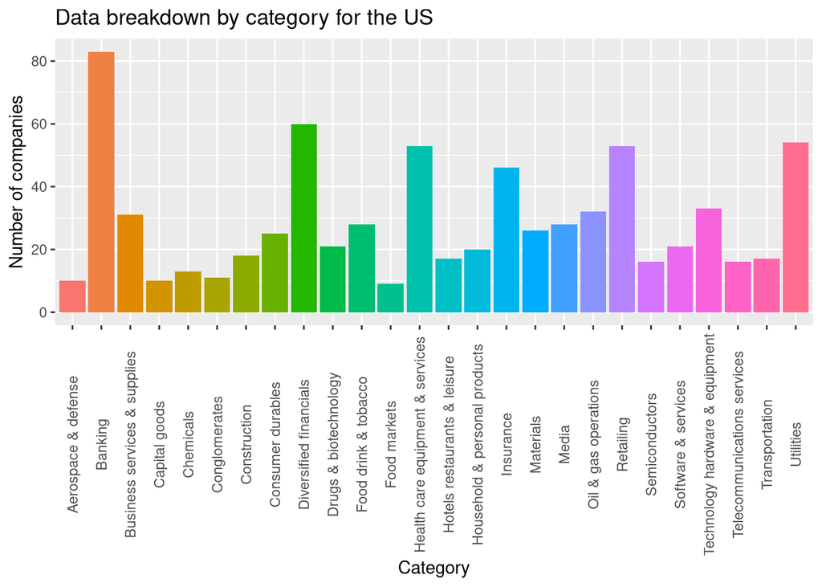

```r
ggplot(usComp, aes(x=category, fill = category))+ geom_bar()+theme(axis.text.x = element_text(angle = 90, vjust = 0.5))+theme(legend.position="none")+labs(x='Category', y='Number of companies', title = 'Data breakdown by category for the US')
```

Banking holds the biggest category within the dataset for the US, with a not-so-close second place going to diversified financials.

### Japanese Companies

```r
jpComp <- forbes[country=='Japan']
nrow(jpComp)
```

```
## [1] 316
```

```r
jpComp %>% kable %>% kable_styling("striped", full_width = F) %>% scroll_box( height = "350px")
```

| V1 | rank | name | country | category | sales | profits | assets | marketvalue | antirank |
| --- | --- | --- | --- | --- | --- | --- | --- | --- | --- |
| 8 | 8 | Toyota Motor | Japan | Consumer durables | 135.82 | 7.99 | 171.71 | 115.40 | 1992 |
| 30 | 30 | Nippon Tel & Tel | Japan | Telecommunications services | 92.41 | 2.17 | 150.87 | 73.00 | 1970 |
| 49 | 49 | Honda Motor | Japan | Consumer durables | 67.44 | 3.61 | 63.09 | 40.61 | 1951 |
| 51 | 51 | Nissan Motor | Japan | Consumer durables | 57.77 | 4.19 | 60.56 | 41.71 | 1949 |
| 72 | 72 | Tokyo Electric Power | Japan | Utilities | 41.62 | 1.40 | 116.68 | 30.63 | 1928 |
| 82 | 82 | Sony | Japan | Consumer durables | 63.23 | 0.98 | 68.04 | 38.00 | 1918 |
| 138 | 138 | Canon | Japan | Business services & supplies | 24.76 | 1.61 | 23.34 | 42.84 | 1862 |
| 143 | 143 | East Japan Railway | Japan | Transportation | 21.71 | 0.83 | 56.79 | 20.07 | 1857 |
| 156 | 156 | Mitsubishi | Japan | Trading companies | 112.76 | 0.46 | 67.69 | 15.13 | 1844 |
| 157 | 157 | Kansai Electric Power | Japan | Utilities | 22.12 | 0.68 | 60.52 | 17.56 | 1843 |
| 159 | 159 | Millea Holdings | Japan | Insurance | 24.16 | 0.48 | 83.23 | 22.97 | 1841 |
| 171 | 171 | Chubu Electric Power | Japan | Utilities | 18.41 | 0.90 | 52.08 | 15.59 | 1829 |
| 205 | 205 | Hitachi | Japan | Business services & supplies | 69.30 | 0.24 | 77.32 | 21.09 | 1795 |
| 209 | 209 | Denso | Japan | Consumer durables | 19.74 | 0.94 | 19.60 | 17.20 | 1791 |
| 211 | 211 | KDDI | Japan | Telecommunications services | 23.56 | 0.49 | 23.36 | 23.55 | 1789 |
| 225 | 225 | Mitsui & Co | Japan | Trading companies | 111.98 | 0.28 | 54.88 | 12.30 | 1775 |
| 226 | 226 | Takeda Chemical Inds | Japan | Drugs & biotechnology | 8.85 | 2.30 | 17.37 | 37.96 | 1774 |
| 232 | 232 | Central Japan Railway | Japan | Transportation | 11.53 | 0.42 | 46.05 | 20.66 | 1768 |
| 234 | 234 | Japan Tobacco | Japan | Food drink & tobacco | 16.46 | 0.64 | 24.48 | 14.84 | 1766 |
| 250 | 250 | Fuji Photo Film | Japan | Household & personal products | 21.20 | 0.41 | 24.30 | 15.00 | 1750 |
| 266 | 266 | Ito-Yokado | Japan | Food markets | 28.32 | 0.38 | 20.97 | 14.46 | 1734 |
| 277 | 277 | Mitsui Sumitomo Ins | Japan | Insurance | 15.98 | 0.28 | 54.50 | 12.49 | 1723 |
| 281 | 281 | Tohoku Electric Power | Japan | Utilities | 13.48 | 0.52 | 34.49 | 8.67 | 1719 |
| 285 | 285 | Kyushu Electric Power | Japan | Utilities | 12.02 | 0.54 | 34.69 | 8.48 | 1715 |
| 293 | 293 | Ricoh | Japan | Business services & supplies | 14.71 | 0.61 | 15.11 | 13.50 | 1707 |
| 295 | 295 | Aeon | Japan | Retailing | 26.14 | 0.43 | 16.75 | 11.31 | 1705 |
| 309 | 309 | Mitsubishi Heavy Inds | Japan | Capital goods | 21.94 | 0.29 | 30.59 | 9.82 | 1691 |
| 311 | 311 | Bridgestone | Japan | Consumer durables | 18.93 | 0.38 | 17.07 | 12.86 | 1689 |
| 314 | 314 | Sumitomo | Japan | Trading companies | 78.08 | 0.24 | 40.69 | 7.78 | 1686 |
| 329 | 329 | Toshiba | Japan | Business services & supplies | 47.85 | 0.16 | 39.73 | 13.27 | 1671 |

[output cut: 286 more lines]

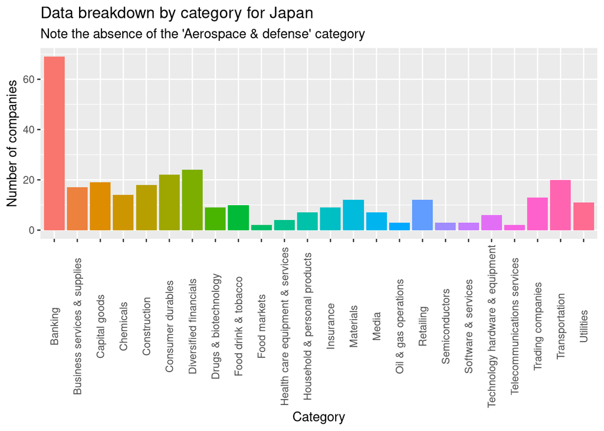

```r
ggplot(jpComp, aes(x=category, fill = category))+ geom_bar()+theme(axis.text.x = element_text(angle = 90, vjust = 0.5))+theme(legend.position="none")+labs(x='Category', y='Number of companies', title = 'Data breakdown by category for Japan', subtitle = "Note the absence of the 'Aerospace & defense' category")
```

Banking also takes the win here, with an even less close second place of Diversified Financials. Japan does not have as many clear spikes in frequency as seen with the US.

### Comparison

To find the higher ranking country, I am going to calculate the median rank for each. I will first create a boxplot of each:

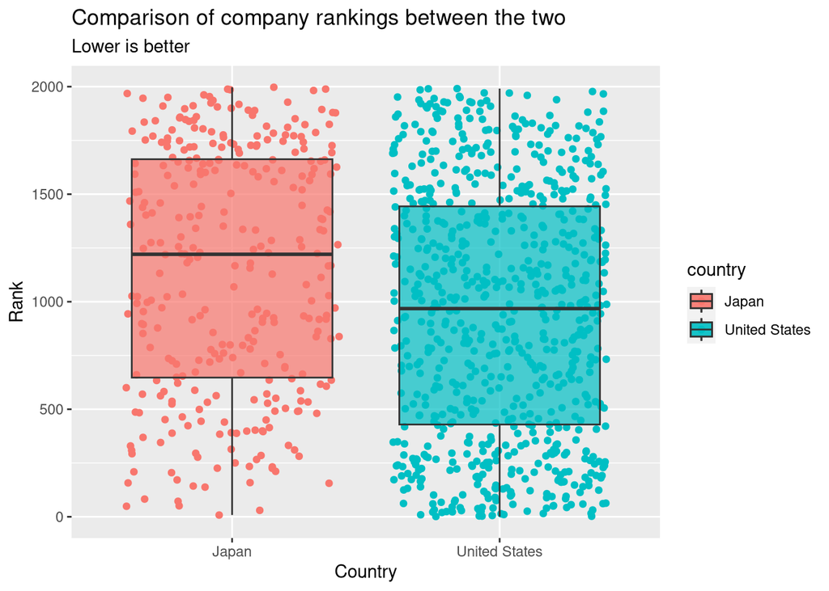

```r
## The joys of ggplot2
ggplot(usComp, aes(x= country, y=rank, fill=country))+geom_jitter(aes(color=country))+geom_boxplot(alpha = 0.7)+geom_jitter(data=jpComp, aes(color = country))+geom_boxplot(data=jpComp, alpha =0.7 )+labs(title = 'Comparison of company rankings between the two', subtitle = 'Lower is better',x='Country', y= 'Rank')
```

This boxplot shows that the United States consistently ranks higher on the chart (lower rank number).

## Part 3: Creating a model of the data

Model from assets, market value, and sales

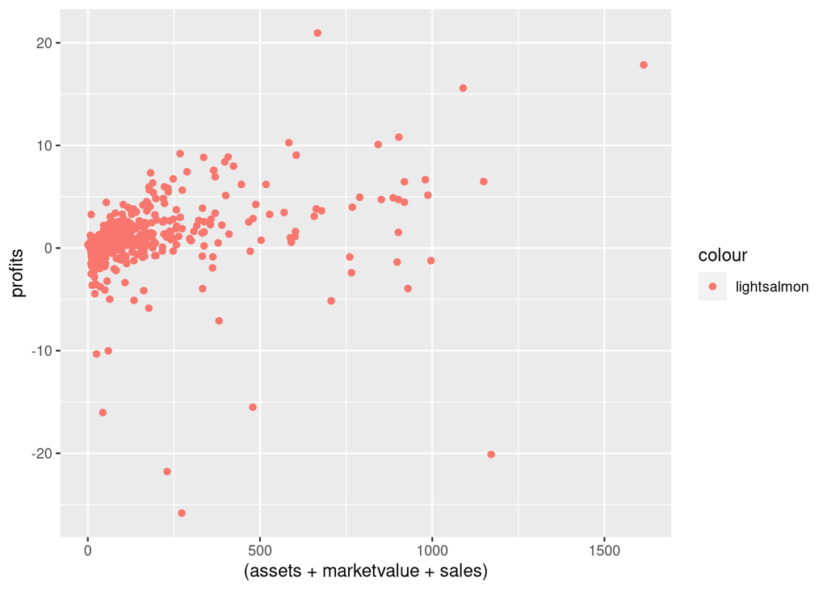

```r
# water reservoir %>% my sink %>% sewers %>% hopefully a treatment plant %>% the river
modelData <- forbes %>% select(c(assets, marketvalue, sales, profits))
modelData %>% ggplot(aes(x=(assets+ marketvalue+ sales), y= profits, color = 'lightsalmon'))+geom_point()
```

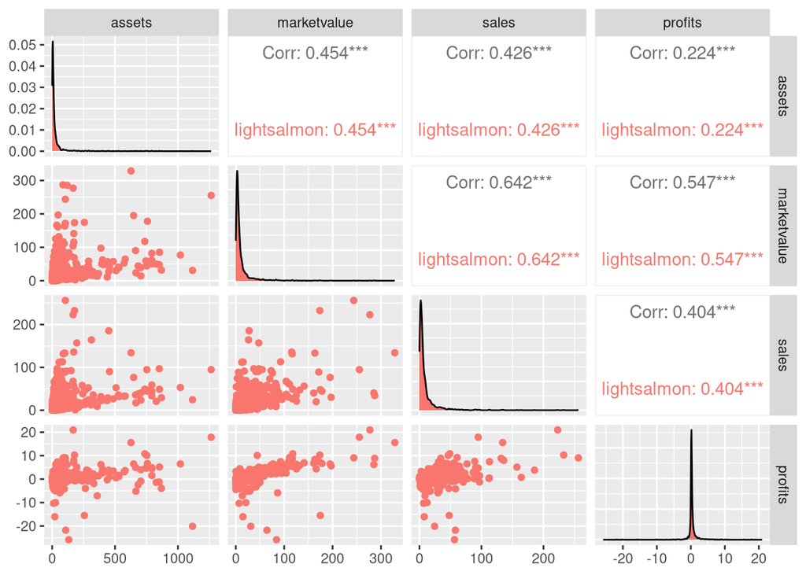

```r
ggpairs(modelData, aes(color = 'lightsalmon'))
```

The correlation between the three input variables appears to be more than a bit correlated, but this could possibly be equated to the high concentration of points surrounding the origin. This will probably not have a major effect on the model.

Making the model and testing it

```r
profModel <- lm(profits ~ assets+ marketvalue+sales, data = modelData)
summary(profModel)
```

```
##
## Call:
## lm(formula = profits ~ assets + marketvalue + sales, data = modelData)
##
## Residuals:
##      Min       1Q   Median       3Q      Max
## -29.2169  -0.0189   0.1160   0.2107   8.9495
##
## Coefficients:
##               Estimate Std. Error t value Pr(>|t|)
## (Intercept) -0.1186259  0.0380039  -3.121  0.00183 **
## assets      -0.0008395  0.0003781  -2.220  0.02651 *
## marketvalue  0.0363340  0.0018183  19.982  < 2e-16 ***
## sales        0.0098892  0.0024331   4.064    5e-05 ***
## ---
## Signif. codes:  0 '***' 0.001 '**' 0.01 '*' 0.05 '.' 0.1 ' ' 1
##
## Residual standard error: 1.472 on 1991 degrees of freedom
##   (5 observations deleted due to missingness)
## Multiple R-squared:  0.3059, Adjusted R-squared:  0.3049
## F-statistic: 292.5 on 3 and 1991 DF,  p-value: < 2.2e-16
```

Looking at the summary of the model created, market value seems to have the largest effect on the calculated profit, with a ~3.6% increase on the profit per 1% increase in market value. Assets have an almost negligible negative effect on the calculation with a -0.08% estimated effect. Sales has a +0.9% effect, meaning higher sales appear to contribute to increases in profit.

```r
anova(profModel)
```

```
## Analysis of Variance Table
##
## Response: profits
##               Df Sum Sq Mean Sq F value    Pr(>F)
## assets         1  312.8  312.84  144.40 < 2.2e-16 ***
## marketvalue    1 1552.8 1552.77  716.71 < 2.2e-16 ***
## sales          1   35.8   35.79   16.52 5.001e-05 ***
## Residuals   1991 4313.6    2.17
## ---
## Signif. codes:  0 '***' 0.001 '**' 0.01 '*' 0.05 '.' 0.1 ' ' 1
```

Plotting the model:

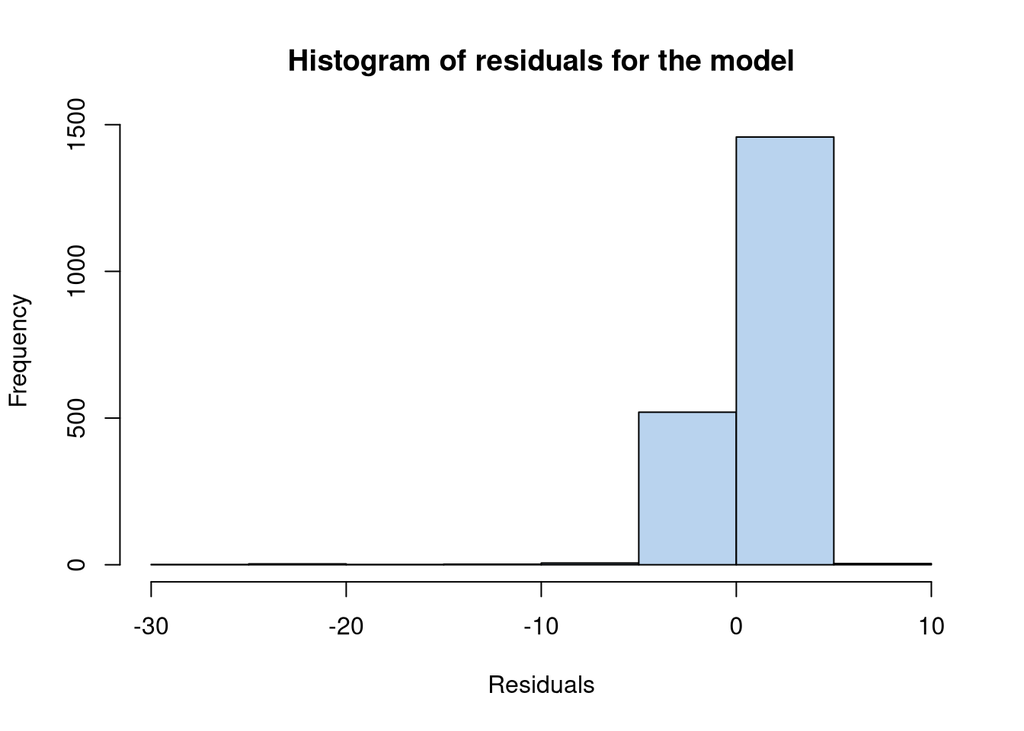

```r
hist(residuals(profModel), col = 'slategray2', main = 'Histogram of residuals for the model', xlab = 'Residuals')
```

The residuals of this model are extremely biased and the distribution is skewed quite left.

#### Model Results

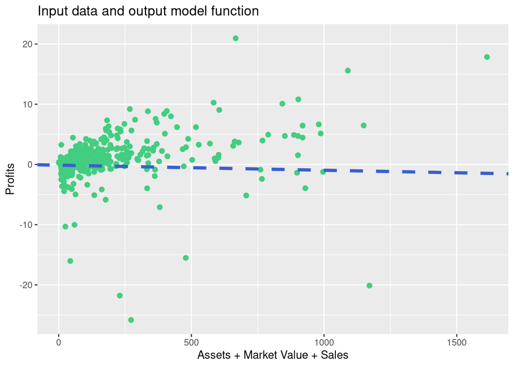

```r
# Have they made a ggplot version that can just read my mind and format the plot exactaly how I want?
modelData %>% ggplot(aes(x=(assets+ marketvalue+ sales), y= profits))+geom_point(color = '#43CD80', size = 2, )+geom_abline(slope=coef(profModel)[2], intercept = coef(profModel)[1], color='royalblue3', size = 1.5, linetype = 'dashed') + labs(x='Assets + Market Value + Sales', y='Profits', title = 'Input data and output model function')
```

Overall, this is a pretty poor model for predicting the profits. I may have spoke too quickly when I said the high correlation wasn’t an issue. One of the causes of a poor model could be the variety in the way different countries handle economics, corporate regulations, etc.

## Part 4: The Model II - Making one for both the US and Japan

### USA

#### Input Data:

We already have the data subsetted from part 2

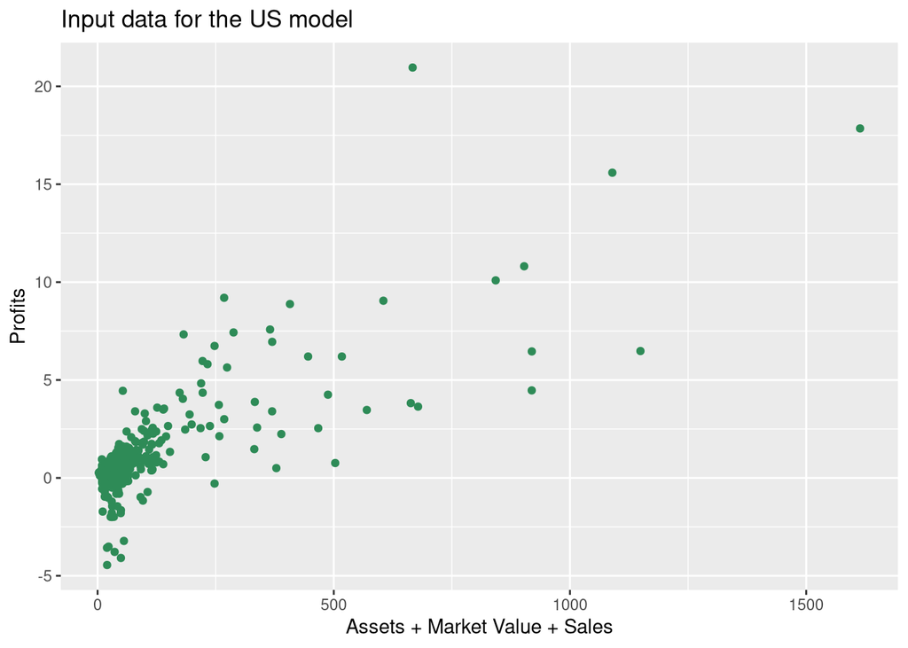

```r
usCompMod <- usComp %>% select(c(profits, assets, marketvalue, sales))
usCompMod %>% ggplot(aes(x=(assets+ marketvalue+ sales), y= profits))+geom_point(color = 'seagreen')+labs(x='Assets + Market Value + Sales', y='Profits', title = 'Input data for the US model')
```

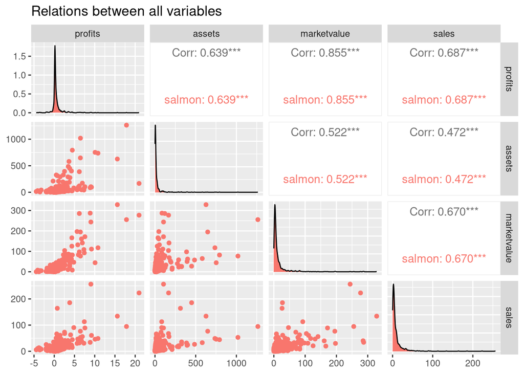

```r
ggpairs(usCompMod, aes(color = 'salmon'), title = 'Relations between all variables')
```

```r
# Does ggpairs have a quiet mode?
```

#### US model creation

```r
usModel <- lm(profits~assets+marketvalue+sales, data = usCompMod)
summary(usModel)
```

```
##
## Call:
## lm(formula = profits ~ assets + marketvalue + sales, data = usCompMod)
##
## Residuals:
##     Min      1Q  Median      3Q     Max
## -4.4954 -0.0620  0.1217  0.1953  7.8811
##
## Coefficients:
##               Estimate Std. Error t value Pr(>|t|)
## (Intercept) -0.1465337  0.0336610  -4.353 1.53e-05 ***
## assets       0.0043831  0.0003655  11.993  < 2e-16 ***
## marketvalue  0.0339639  0.0012747  26.645  < 2e-16 ***
## sales        0.0138408  0.0020376   6.793 2.25e-11 ***
## ---
## Signif. codes:  0 '***' 0.001 '**' 0.01 '*' 0.05 '.' 0.1 ' ' 1
##
## Residual standard error: 0.8118 on 744 degrees of freedom
##   (3 observations deleted due to missingness)
## Multiple R-squared:  0.795,  Adjusted R-squared:  0.7942
## F-statistic: 961.8 on 3 and 744 DF,  p-value: < 2.2e-16
```

```r
anova(usModel)
```

```
## Analysis of Variance Table
##
## Response: profits
##              Df Sum Sq Mean Sq  F value    Pr(>F)
## assets        1 975.23  975.23 1479.783 < 2.2e-16 ***
## marketvalue   1 895.96  895.96 1359.498 < 2.2e-16 ***
## sales         1  30.41   30.41   46.142 2.253e-11 ***
## Residuals   744 490.32    0.66
## ---
## Signif. codes:  0 '***' 0.001 '**' 0.01 '*' 0.05 '.' 0.1 ' ' 1
```

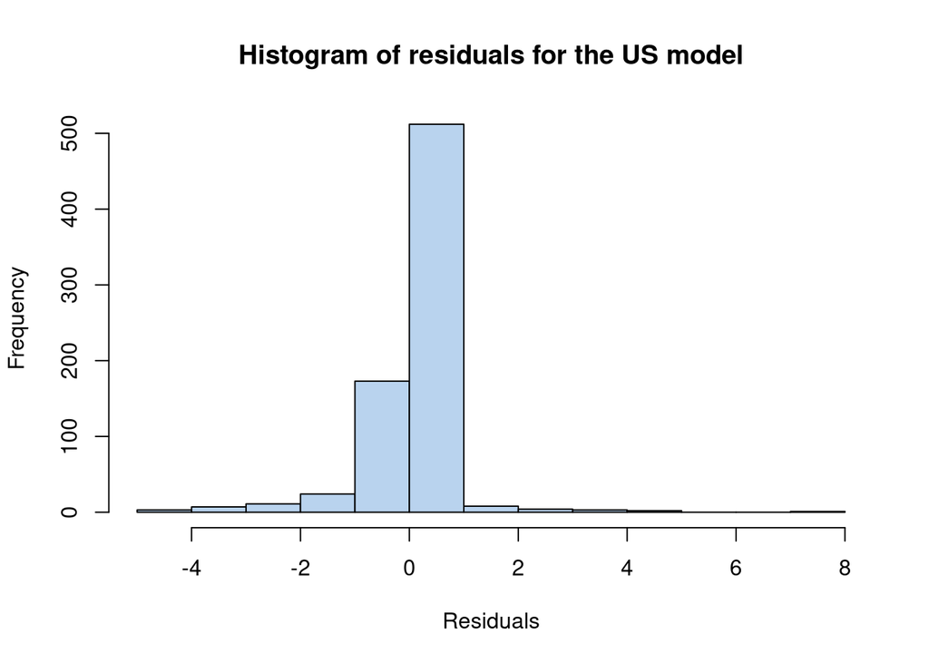

```r
hist(residuals(usModel), col = 'slategray2', main = 'Histogram of residuals for the US model', xlab = 'Residuals')
```

This model fits the data much better. The r-squared value is 0.79, the t-values are higher with much lower associated p-values. The residuals are more normally distributed, but show major bias in the ~ 1 area. This bias is countered by the second-largest group, right below 0.

#### US model plot:

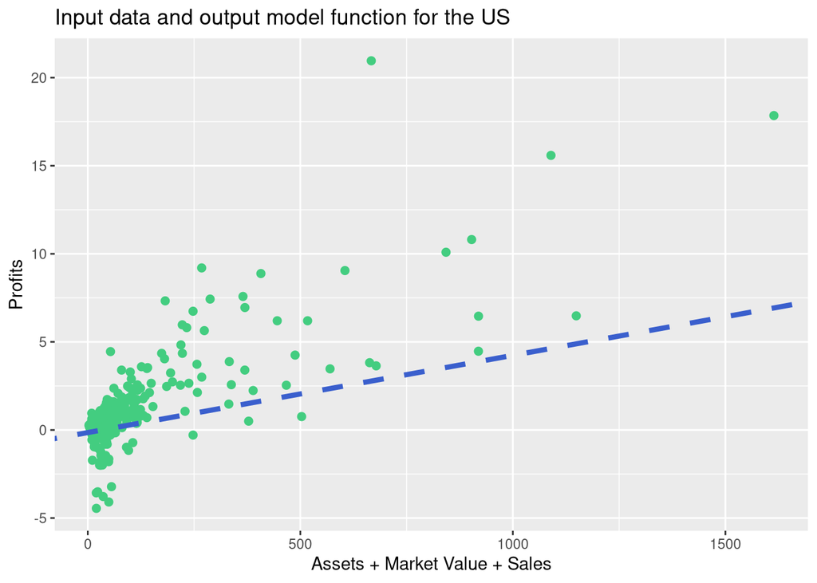

```r
usCompMod %>% ggplot(aes(x=(assets+ marketvalue+ sales), y= profits))+geom_point(color = '#43CD80', size = 2)+geom_abline(slope=coef(usModel)[2], intercept = coef(usModel)[1], color='royalblue3', linetype = 'dashed', size = 1.5)+labs(x='Assets + Market Value + Sales', y='Profits', title = 'Input data and output model function for the US')
```

### Japan

#### Input Data:

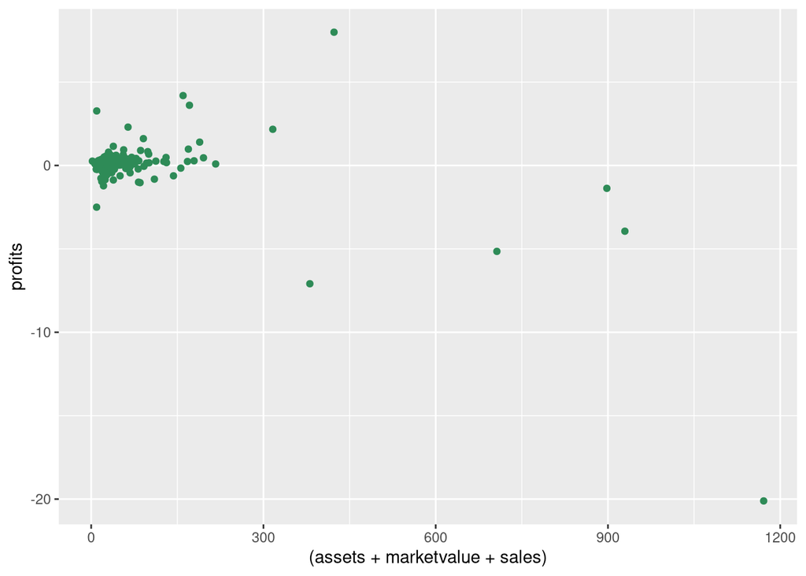

```r
jpCompMod <- jpComp %>% select(c(profits, assets, marketvalue, sales))
jpCompMod %>% ggplot(aes(x=(assets+ marketvalue+ sales), y= profits))+geom_point(color = 'seagreen')
```

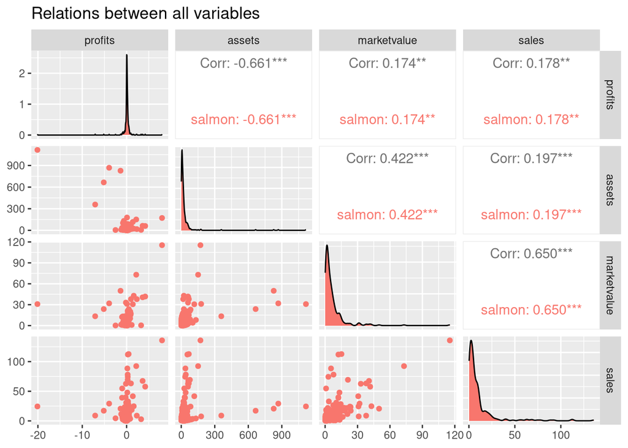

```r
# ggpairs, the exact thing I needed but with even more confusing asthetics bindings
ggpairs(jpCompMod, aes(color = 'salmon'), title = 'Relations between all variables')
```

Japan’s input data has the lowest correlation between variables of the three models. This would in theory mean a stronger, less-incorrect model.